# RLs from Fish Metals

T.Hooker

24 March, 2019

```r
#options(table_counter=FALSE)
tidy_package <- c("plyr", "dplyr", "tidyr", "magrittr")
if(!"tidyr" %in% (.packages())) {invisible(lapply(tidy_package, library, character.only=T, quietly = T, warn.conflicts = F))}
# graph_package <- c("ggplot2", "scales")
options(scipen = 999, digits = 4, stringsAsFactors = FALSE)
##
#startwork.date <- format(Sys.Date(), "%y%m%d")
knitr::opts_chunk$set(cache=TRUE)
```

### Notes

Examination of Fish Se/Hg RLs from currently available data

### 1.0 Data

```r
# file_00 <- choose.files(caption="Select DATA files [*.xlsx]", multi = TRUE)
# DAT_00 <- openxlsx::read.xlsx(file_00, sheet="Master list", colNames=T, startRow = 8,
#                                             rowNames=FALSE, check.names = T)
#
# DAT_00 <- DAT_00[-c(4719, 4720),]
dat0 <- DAT_00
```

- Filename :: UtahFishTissueData (2000-2017)master_working_tdh01.xlsx
- Path :: U:/ENG_WQ/tobyhooker/DATA MANAGEMENT & QA/DATA.Projects/Fish_Metals_labs
- Last Accessed :: [2019-03-22 08:43:06]

#### 1.1 Dataset characteristics

```r
class(dat0$Hg.Result.ug.g)
```

```
[1] "character"
```

```r
class(dat0$Se.Result.ug.g)
```

```
[1] "numeric"
```

- Convert RVs w/ “<” to U-flag
- Also remove footnotes [!!]

```r
dat0 %<>% mutate(Hg_flag = as.character(NA),
                 HG_rv2 = as.numeric(NA)) %>% mutate(
    Hg_flag = case_when(
        grepl("<", .$Hg.Result.ug.g) ~ "U",
        TRUE ~ as.character(NA)),
    #
    HG_rv2 = case_when(
        !is.na(as.numeric(.$Hg.Result.ug.g)) ~ as.numeric(Hg.Result.ug.g),
        grepl("[[:punct:]]", .$Hg.Result.ug.g) &
            is.na(Hg_flag) ~
            as.numeric(
                stringr::str_split(
                    .$Hg.Result.ug.g,
                    " ", 2, simplify = T)[,1]),
        grepl("[[:punct:]]", .$Hg.Result.ug.g) &
            !is.na(Hg_flag) ~
            as.numeric(
                stringr::str_split(
                    gsub("<", "", .$Hg.Result.ug.g),
                    " ", 2, simplify = T)[,1],
                TRUE ~ as.numeric(NA))
    )) %>%
    select(Site.Code:Year.Sampled, Hg_flag, Hg.Result.ug.g, HG_rv2,
           everything())
```

- Se_results are all numeric, and okay

#### 1.2 Non-Detects

- 90 Hg results were below detection, out of 4707
- Analyses for Hg by Lab

```r
dat0 %>%
    {addmargins(table(.$Lab.Tested, is.na(.$HG_rv2), useNA="ifany", deparse.level=2))}
```

```
                           is.na(.$HG_rv2)
.$Lab.Tested                FALSE TRUE  Sum
  ACZ (Cold Vapor)             48    0   48
  DNP                           0    2    2
  EPA                        3071    4 3075
  EPA-Corvallis               265    0  265
  National Pesticides Study    10    0   10
  Texas                       263    2  265
  Texas A&M                    19    0   19
  UPHL                       1026    3 1029
  USU                           5    0    5
  Sum                        4707   11 4718
```

- 9 labs in dataset, to date

```r
dat0 %>%
    {addmargins(table(.$Lab.Tested, is.na(.$Hg_flag), useNA="ifany", deparse.level=2))}
```

```
                           is.na(.$Hg_flag)
.$Lab.Tested                FALSE TRUE  Sum
  ACZ (Cold Vapor)              4   44   48
  DNP                           0    2    2
  EPA                          86 2989 3075
  EPA-Corvallis                 0  265  265
  National Pesticides Study     0   10   10
  Texas                         0  265  265
  Texas A&M                     0   19   19
  UPHL                          0 1029 1029
  USU                           0    5    5
  Sum                          90 4628 4718
```

```r
# unique(dat0$Lab.Tested)
```

- Only two labs have reported `Non-Detect` values (*U-flag*) for Hg results, ACZ and EPA

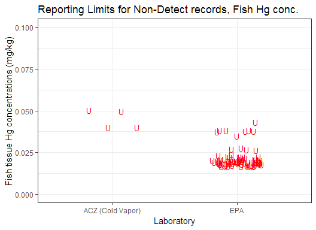

- RLs versus Quantitated results by laboratory

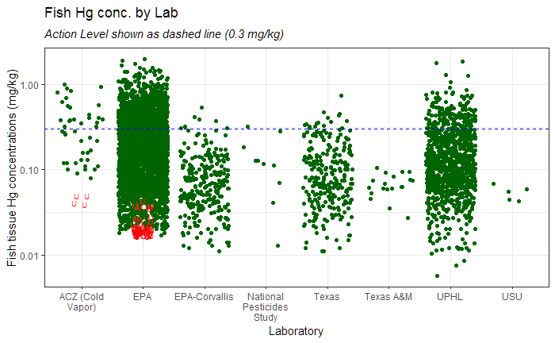

```r
dat0 %>%
    filter(!is.na(HG_rv2)) %>%
    filter(is.na(Hg_flag)) %>%
    ggplot(., aes(y = HG_rv2, x = Lab.Tested)) + theme_bw() +
    geom_point(position= position_jitter(width=0.4),
               fill="darkgreen", col="darkgreen", shape=19,  size=1.5, na.rm=T) +
    geom_point(data=filter(dat0, !is.na(HG_rv2) & !is.na(Hg_flag)),
               aes(y = HG_rv2, x = Lab.Tested),
               col="red", shape="U", size=1, stroke=2, na.rm=T,
               position= position_jitter(width=0.15, height=0.01)) +
    labs(title= expression("Fish Hg conc. by Lab"),
         subtitle=expression(italic('Action Level shown as dashed line (0.3 mg/kg)'))) +
    xlab("Laboratory") + ylab("Fish tissue Hg concentrations (mg/kg)") +
    scale_y_continuous(limits = c(NA,NA), trans="log10") +
    scale_x_discrete(labels=wrap_format(10)) +
    geom_hline(yintercept=0.3, lty=2, col="blue")
```

```r
# coord_flip()
# labels=function(x) stringr::str_wrap(x, width=10)
```

- Working from a Hg-in-Fish tissue action level of 0.3 mg/kg, and applying a 5x rule for reporting levels relative to the action level, RLs should be *at most* 0.06 mg/kg
- Similarly, for Se-in-Fish tissue action levels of 11.3 mg/kg and applying the same 5x RL rule, RLs should be *at most* 2.26 mg/kg (*a better level of quantitation would require RLs no more than 1.13 mg/kg*)
- Only EPA Lab provided results for SE

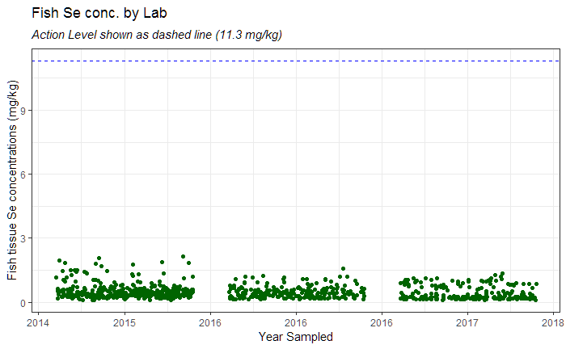

```r
dat0 %>%
    filter(!is.na(Se.Result.ug.g)) %>%
    ggplot(., aes(y = Se.Result.ug.g, x = Year.Sampled)) + theme_bw() +
    geom_point(position= position_jitter(width=0.4),
               fill="darkgreen", col="darkgreen", shape=19,  size=1.5, na.rm=T) +
    labs(title= expression("Fish Se conc. by Lab"),
         subtitle=expression(italic('Action Level shown as dashed line (11.3 mg/kg)'))) +
    xlab("Year Sampled") + ylab("Fish tissue Se concentrations (mg/kg)") +
    scale_y_continuous(limits = c(NA,NA)) +
    geom_hline(yintercept=11.3, lty=2, col="blue")
```

```r
# coord_flip()
# labels=function(x) stringr::str_wrap(x, width=10)
```

**Note :: The action levels reported are on dry-weight basis. These ALs need to be re-scaled…, see WORD doc**

## WORK

```r
if(!"tidyr" %in% (.packages())) {invisible(lapply(tidy_package, library, character.only=T, quietly = T, warn.conflicts = F))}
# table(Lakes$ACT.type, Lakes$SampType_x)
# Lakes %>% {addmargins(table(.$QC_type,.$Import_type,useNA="ifany",deparse.level = 2))}
# x$SKey1_x[duplicated(x$SKey1_x)]
### options for loading .RData files and getting either (i) known df-names, or (ii) finding df-names
## (i)  obj2 <- get(load("201718wy_FLDimport_FLOW_import04_181211.RData"))
## (ii) obj <- load("201718wy_FLDimport_FLOW_import04_181211.RData")
## (ii-cont) obj  ## this line gives the name of the imported / loaded DF
# LabRef$Sample.Received.Date <- as.Date(LabRef$Sample.Received.Date, origin="1899-12-30")
# LabRef$Sample.Date <- as.Date(LabRef$Sample.Date, origin="1899-12-30")
# as.Date(42871, origin="1899-12-30")
# select(data06, contains("SDate", ignore.case = T))
# select(data08_rename, contains("Comment", ignore.case = T)) %>% names(.)
# select(data09_X, contains("Equipment", ignore.case = T)) %>% names(.)
# openxlsx::write.xlsx(Data.Vars, file=paste("wy201718_data07_dVARS_",
#                                            format(Sys.Date(),"%y%m%d"),
#                                            ".xlsx", sep=""))
```

## END

```r
lastwork.date <- format(Sys.Date(), "%y%m%d")
```

**Start work date ::** 190324  
**Last work date ::** 190326  
**Current review date ::** 190326

eof